# CIS 544 - Homework Assignment 5

FirstName LastName. FLastName@stu.edu

# Homework Assignment 5

Consider the 2-dimensional data in the file `clusterThis.csv`

```r
library(tidyverse)
hwlink <- "https://raw.githubusercontent.com/reisanar/datasets/master/clusterThis.csv"
hwdata <- read_csv(hwlink)
```

### — Problem 1 —

- Plot the points in the data set

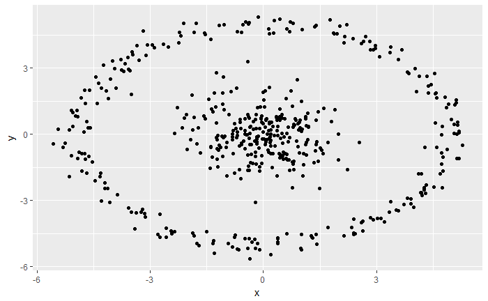

```r
ggplot(hwdata, aes(x=x,y=y)) +
  geom_point()
```

- Do you see any type of clusters/groups right away? I see two clusters the outter ring group and the inner group
- Use **k-means** to try to find two (2) clusters in this dataset. Use the base R function `kmeans()`:

```r
# use the function kmeans()
km_eye<-kmeans(hwdata, centers = 2)
km_eye_results<-as.factor(km_eye$cluster)
```

- Plot the points again colored by the associated cluster found in the previous step

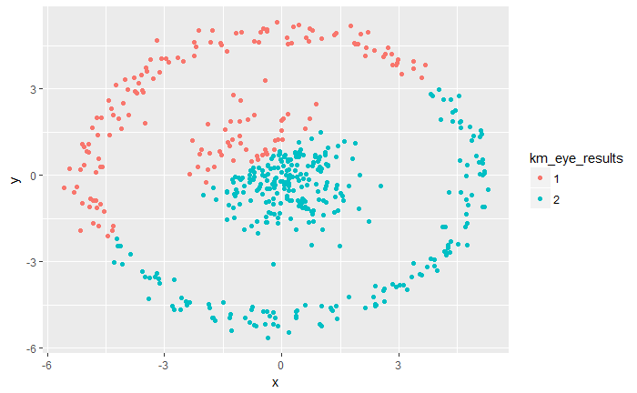

```r
# plot the points colored by cluster assignment
ggplot(hwdata, aes(x=x,y=y,color=km_eye_results)) +
  geom_point()
```

The points got split in half instead of being split between the inner and outter circles.

### — Problem 2 —

- Use **hierarchical clustering** (with a single linkage) to try to find the groups in this dataset. You can use the `hclust()` function from base R.

```r
# use hclust for hierarchical clustering
dis_hw<-dist(hwdata)
hc_hw<-hclust(dis_hw,method = "single")
```

- Cut the dendrogram tree to 2 clusters using the `cutree()` function

```r
# cut dendrogram
cut1<-cutree(hc_hw,2)
hc_hwr<-as.factor(cut1)
```

- Plot the points with this new cluster assignment:

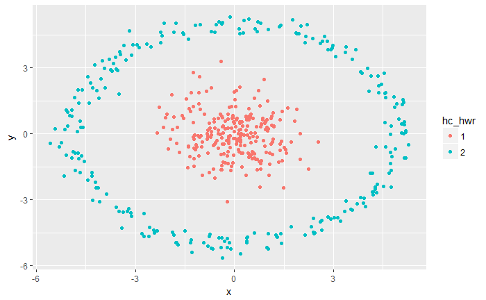

```r
# points colored by hierarchical clustering results
ggplot(hwdata, aes(x=x,y=y,color=hc_hwr)) +
  geom_point()
```

### — Problem 3 —

- We can use a transformation on the data set to help with the clustering problem. For example, transforming the data into [polar coordinates](http://en.wikipedia.org/wiki/Polar_coordinate_system) might be a good idea in this case.

For this, simply use:

```r
polar <- hwdata %>%
          transform(r = sqrt(x^2 + y^2), theta=atan(y/x))
polar
```

| x | y | r | theta |
| --- | --- | --- | --- |
| -1.545448388 | 0.697142112 | 1.6954108 | -0.423763119 |
| -0.528393243 | -0.299152891 | 0.6072000 | 0.515162216 |
| -1.086758791 | 1.360181377 | 1.7410164 | -0.896677163 |
| -0.000111512 | 1.920287471 | 1.9202875 | -1.570738256 |
| 0.388953783 | -0.053646534 | 0.3926360 | -0.137060463 |
| 0.532631272 | -0.797838160 | 0.9592923 | -0.982152602 |
| -1.837571660 | 0.769780319 | 1.9922930 | -0.396702545 |
| 0.650598453 | -0.342328601 | 0.7351648 | -0.484367625 |
| -0.624245435 | 0.686505150 | 0.9278856 | -0.832861774 |
| 0.891555027 | 2.488660267 | 2.6435393 | 1.226793506 |

[output cut: 490 more lines]

- Use these new coordinates (`r` and `theta`) to try clustering using k-means (make sure to use the `kmeans()` function with the right columns! Use `centers=2`)

```r
# kmeans clustering on transformed points:
km_newcor<-kmeans(polar[,c("r","theta")],centers=2)
km_newcorre<-as.factor(km_newcor$cluster)
```

- Plot the points again with this new assignment of clusters:

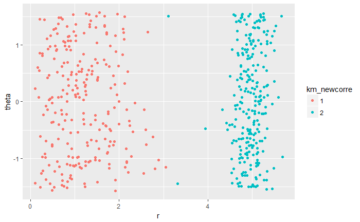

```r
# new plot: new assignment from k-means
ggplot(polar, aes(x=r,y=theta,color=km_newcorre)) +
  geom_point()
```

- Is this a better cluster assignment with k-means than from problem 1?

I would say it does look better with two distinctive groups side by side rather than the planet looking cluster from the k-means. In this cluster the groups can be explained better than the other cluster from problem one.